# PracticaPart2_Visualitzacio_AinaParareda (2)

[figure not shown]

M2.959 - Visualització de dades

Màster en Ciència de Dades

Aina Parareda Casablancas

Juny del 2025

## **Projecte de visualització (Part II)**

**1. Introducció i objectius**

Aquest projecte de visualització de dades s'emmarca dins del context educatiu de Catalunya i utilitza un conjunt de dades oficials proporcionades pel Departament d'Educació. L'objectiu és explorar i visualitzar de manera clara i interactiva com es distribueixen els alumnes segons factors com el tipus d'ensenyament, el sexe, la titularitat del centre, i la geografia.

Els principals objectius del projecte són:

- Mostrar les diferències de gènere en funció del tipus d'estudi.
- Analitzar la distribució territorial dels alumnes i les unitats educatives.
- Explorar possibles desequilibris entre titularitat pública i privada segons la zona.
- Detectar comarques amb alta pressió educativa (molts alumnes per unitat).
- Identificar ensenyaments amb segregació de gènere significativa.

La visualització pretén posar en relleu patrons ocults, fomentar una millor comprensió del sistema educatiu i obrir la porta a reflexions sobre equitat i planificació territorial.

**2. Carregant i preparant les dades**

Descripció breu del conjunt de dades

- Origen: Portal de Dades Obertes de la Generalitat de Catalunya
- Departament responsable: Educació i Formació Professional
- Data d’actualització: 9 d’abril de 2025
- Àmbit geogràfic: Catalunya
- Freqüència: Anual
- Nombre de registres: 389.369
- Nombre de columnes: 36
- Contingut: dades sobre alumnes matriculats, unitats docents, titularitat del centre, modalitat d’ensenyament, sexe, ubicació territorial i coordenades geogràfiques.

Aquest conjunt de dades ofereix una visió detallada i oficial del sistema educatiu català, útil per analitzar desigualtats, concentracions, patrons de distribució i possibles biaixos de gènere.

**Eines** **escollides**

Per aquest projecte he escollit **Google Colab** com a entorn de treball, ja que em permet combinar de manera senzilla i fluida codi, visualitzacions i explicacions en un únic document. Aquesta eina facilita afegir tant text com codi en cel·les separades, la qual cosa afavoreix una presentació clara i estructurada del procés analític. A més, Colab ofereix compatibilitat amb llibreries que permeten crear gràfiques interactives, fet que resulta especialment útil per fer exploracions dinàmiques de les dades i comunicar resultats d'una manera més visual i accessible.

Un altre avantatge important és que Colab està integrat dins l'ecosistema de Google Drive, i per tantes pot utilitzar fàcilment amb el compte institucional de la UOC. Això em permet tenir el projecte guardat al núvol, accedir-hi des de qualsevol dispositiu i compartir-lo fàcilment amb el professorat. Aquesta accessibilitat i flexibilitat fan que sigui una eina molt adequada per al desenvolupament de projectes com aquest.

Per a fer públic aquest treball l'he penjat en un repositori de GitHub, juntament amb l'arxiu de dades. L'enllaç del repositori: https://github.com/aparareda/PracticaPart2.git

```python
from google.colab import drive
drive.mount('/content/drive')
```

```python
import pandas as pd

# Carrego el fitxer des del meu Drive
path = '/content/drive/MyDrive/Visualització de dades/Alumnes_matriculats_per_ensenyament_i_unitats_dels_centres_docents_20250430.csv'
df = pd.read_csv(path, low_memory=False)

# Faig una taula mostrant totes les columnes
from IPython.display import HTML

# Selecciono 20 files saltejades (per exemple, cada 5 files fins a tenir 20 files)
df_saltejat = df.iloc[::5].head(20)

# Mostro la taula amb totes les columnes
HTML(df_saltejat.to_html(notebook=True, max_cols=1000))
```

|  | Curs | Any | Codi centre | Denominació completa | Codi naturalesa | Nom naturalesa | Codi titularitat | Nom titularitat | Codi àrea territorial | Nom àrea territorial | Codi comarca | Nom comarca | Codi municipi_5 | Codi municipi_6 | Nom municipi | Codi districte municipal | Nom districte municipal | Coordenades UTM X | Coordenades UTM Y | Coordenades GEO X | Coordenades GEO Y | Codi estudis | Nom estudis | Temàtica | Grau | Codi ensenyament | Nom ensenyament | Nivell | Matrícula concertada | … |
| --- | --- | --- | --- | --- | --- | --- | --- | --- | --- | --- | --- | --- | --- | --- | --- | --- | --- | --- | --- | --- | --- | --- | --- | --- | --- | --- | --- | --- | --- | --- |
| 0 | 2023/2024 | 2023 | 8051471 | Escola Josep Maria Folch i Torres | 1 | Públic | 1 | Departament d'Ensenyament | 208 | Barcelonès | 13 | Barcelonès | 8101 | 81017.0 | L'Hospitalet de Llobregat | 05 | Pubilla Casas | 424990.97 | 4580194.75 | 2.103087 | 41.369773 | EPRI | EDUCACIÓ PRIMÀRIA | NaN | NaN | EPRILOE | EDUCACIÓ PRIMÀRIA | 3 | NaN | … |
| 5 | 2023/2024 | 2023 | 8051665 | LLI privada Nostra Senyora | 2 | Privat | 26 | Societats Mercantils | 108 | Consorci d'Educació de Barcelona | 13 | Barcelonès | 8019 | 80193.0 | Barcelona | 05 | Sarrià - Sant Gervasi | 426970.45 | 4583934.82 | 2.126303 | 41.403640 | EINF | EDUCACIÓ INFANTIL | NaN | NaN | EINFLOE 2C | EDUCACIÓ INFANTIL: PARVULARI | 2 | NO | … |
| 10 | 2023/2024 | 2023 | 8052165 | Escola Octavio Paz | 1 | Públic | 1 | Departament d'Ensenyament | 108 | Consorci d'Educació de Barcelona | 13 | Barcelonès | 8019 | 80193.0 | Barcelona | 09 | Sant Andreu | 432273.93 | 4585064.84 | 2.189619 | 41.414282 | EINF | EDUCACIÓ INFANTIL | NaN | NaN | EINFLOE 2C | EDUCACIÓ INFANTIL: PARVULARI | 1 | NaN | … |
| 15 | 2023/2024 | 2023 | 8052165 | Escola Octavio Paz | 1 | Públic | 1 | Departament d'Ensenyament | 108 | Consorci d'Educació de Barcelona | 13 | Barcelonès | 8019 | 80193.0 | Barcelona | 09 | Sant Andreu | 432273.93 | 4585064.84 | 2.189619 | 41.414282 | EPRI | EDUCACIÓ PRIMÀRIA | NaN | NaN | EPRILOE | EDUCACIÓ PRIMÀRIA | 3 | NaN | … |
| 20 | 2023/2024 | 2023 | 8052207 | Institut de Puig-reig | 1 | Públic | 1 | Departament d'Ensenyament | 1060 | Catalunya Central | 14 | Berguedà | 8175 | 81751.0 | Puig-reig | 00 | NaN | 406843.54 | 4647520.30 | 1.875624 | 41.974175 | BATX | BATXILLERAT | NaN | NaN | BATXLOE 2000 | BATXILLERAT DE CIÈNCIES I TECNOLOGIA | 1 | NaN | … |
| 25 | 2023/2024 | 2023 | 8052207 | Institut de Puig-reig | 1 | Públic | 1 | Departament d'Ensenyament | 1060 | Catalunya Central | 14 | Berguedà | 8175 | 81751.0 | Puig-reig | 00 | NaN | 406843.54 | 4647520.30 | 1.875624 | 41.974175 | ESO | EDUCACIÓ SECUNDÀRIA OBLIGATÒRIA | NaN | NaN | ESO LOE | EDUCACIÓ SECUNDÀRIA OBLIGATÒRIA | 2 | NaN | … |
| 30 | 2023/2024 | 2023 | 8052335 | Magnòlia | 2 | Privat | 31 | Associacions | 108 | Consorci d'Educació de Barcelona | 13 | Barcelonès | 8019 | 80193.0 | Barcelona | 08 | Nou Barris | 431337.68 | 4586908.93 | 2.178208 | 41.430812 | EINF | EDUCACIÓ INFANTIL | NaN | NaN | EINFLOE 2C | EDUCACIÓ INFANTIL: PARVULARI | 2 | SI | … |
| 35 | 2023/2024 | 2023 | 8052581 | Institut Miquel Tarradell | 1 | Públic | 1 | Departament d'Ensenyament | 108 | Consorci d'Educació de Barcelona | 13 | Barcelonès | 8019 | 80193.0 | Barcelona | 01 | Ciutat vella | 430448.62 | 4581511.87 | 2.168188 | 41.382126 | BATX | BATXILLERAT | NaN | NaN | BATXLOE 3000 | BATXILLERAT D'HUMANITATS I CIÈNCIES SOCIALS | 2 | NaN | … |
| 40 | 2023/2024 | 2023 | 8052591 | Guimbarda | 2 | Privat | 21 | Cooperatives | 108 | Consorci d'Educació de Barcelona | 13 | Barcelonès | 8019 | 80193.0 | Barcelona | 05 | Sarrià - Sant Gervasi | 427351.75 | 4584549.27 | 2.130790 | 41.409209 | EE | EDUCACIÓ ESPECIAL | NaN | NaN | EE EINF | EDUCACIÓ ESPECIAL INFANTIL | 3 | SI | … |
| 45 | 2023/2024 | 2023 | 8052591 | Guimbarda | 2 | Privat | 21 | Cooperatives | 108 | Consorci d'Educació de Barcelona | 13 | Barcelonès | 8019 | 80193.0 | Barcelona | 05 | Sarrià - Sant Gervasi | 427351.75 | 4584549.27 | 2.130790 | 41.409209 | EE | EDUCACIÓ ESPECIAL | NaN | NaN | EE EPRI | EDUCACIÓ ESPECIAL PRIMÀRIA | 5 | SI | … |
| 50 | 2023/2024 | 2023 | 8052608 | Institut Pau Claris | 1 | Públic | 1 | Departament d'Ensenyament | 108 | Consorci d'Educació de Barcelona | 13 | Barcelonès | 8019 | 80193.0 | Barcelona | 01 | Ciutat vella | 431557.02 | 4582514.45 | 2.181330 | 41.391251 | BATX | BATXILLERAT | NaN | NaN | BATXLOE 2000 | BATXILLERAT DE CIÈNCIES I TECNOLOGIA | 1 | NaN | … |
| 55 | 2023/2024 | 2023 | 8052608 | Institut Pau Claris | 1 | Públic | 1 | Departament d'Ensenyament | 108 | Consorci d'Educació de Barcelona | 13 | Barcelonès | 8019 | 80193.0 | Barcelona | 01 | Ciutat vella | 431557.02 | 4582514.45 | 2.181330 | 41.391251 | ESO | EDUCACIÓ SECUNDÀRIA OBLIGATÒRIA | NaN | NaN | ESO LOE | EDUCACIÓ SECUNDÀRIA OBLIGATÒRIA | 2 | NaN | … |
| 60 | 2023/2024 | 2023 | 8052621 | Escola Pau Romeva | 1 | Públic | 1 | Departament d'Ensenyament | 108 | Consorci d'Educació de Barcelona | 13 | Barcelonès | 8019 | 80193.0 | Barcelona | 04 | Les Corts | 425840.12 | 4580960.71 | 2.113145 | 41.376750 | EINF | EDUCACIÓ INFANTIL | NaN | NaN | EINFLOE 2C | EDUCACIÓ INFANTIL: PARVULARI | 3 | NaN | … |
| 65 | 2023/2024 | 2023 | 8052621 | Escola Pau Romeva | 1 | Públic | 1 | Departament d'Ensenyament | 108 | Consorci d'Educació de Barcelona | 13 | Barcelonès | 8019 | 80193.0 | Barcelona | 04 | Les Corts | 425840.12 | 4580960.71 | 2.113145 | 41.376750 | EPRI | EDUCACIÓ PRIMÀRIA | NaN | NaN | EPRILOE | EDUCACIÓ PRIMÀRIA | 5 | NaN | … |
| 70 | 2023/2024 | 2023 | 8052657 | Escola Fort Pienc | 1 | Públic | 1 | Departament d'Ensenyament | 108 | Consorci d'Educació de Barcelona | 13 | Barcelonès | 8019 | 80193.0 | Barcelona | 02 | Eixample | 431679.12 | 4582944.44 | 2.182741 | 41.395134 | EPRI | EDUCACIÓ PRIMÀRIA | NaN | NaN | EPRILOE | EDUCACIÓ PRIMÀRIA | 1 | NaN | … |
| 75 | 2023/2024 | 2023 | 8052657 | Escola Fort Pienc | 1 | Públic | 1 | Departament d'Ensenyament | 108 | Consorci d'Educació de Barcelona | 13 | Barcelonès | 8019 | 80193.0 | Barcelona | 02 | Eixample | 431679.12 | 4582944.44 | 2.182741 | 41.395134 | EPRI | EDUCACIÓ PRIMÀRIA | NaN | NaN | EPRILOE | EDUCACIÓ PRIMÀRIA | 6 | NaN | … |
| 80 | 2023/2024 | 2023 | 8052669 | Escola Ferran Sunyer | 1 | Públic | 1 | Departament d'Ensenyament | 108 | Consorci d'Educació de Barcelona | 13 | Barcelonès | 8019 | 80193.0 | Barcelona | 02 | Eixample | 430002.05 | 4580787.75 | 2.162931 | 41.375566 | EPRI | EDUCACIÓ PRIMÀRIA | NaN | NaN | EPRILOE | EDUCACIÓ PRIMÀRIA | 1 | NaN | … |
| 85 | 2023/2024 | 2023 | 8052669 | Escola Ferran Sunyer | 1 | Públic | 1 | Departament d'Ensenyament | 108 | Consorci d'Educació de Barcelona | 13 | Barcelonès | 8019 | 80193.0 | Barcelona | 02 | Eixample | 430002.05 | 4580787.75 | 2.162931 | 41.375566 | EPRI | EDUCACIÓ PRIMÀRIA | NaN | NaN | EPRILOE | EDUCACIÓ PRIMÀRIA | 6 | NaN | … |
| 90 | 2023/2024 | 2023 | 8052670 | Escola Auró | 1 | Públic | 1 | Departament d'Ensenyament | 108 | Consorci d'Educació de Barcelona | 13 | Barcelonès | 8019 | 80193.0 | Barcelona | 02 | Eixample | 429117.91 | 4581943.90 | 2.152224 | 41.385901 | EPRI | EDUCACIÓ PRIMÀRIA | NaN | NaN | EPRILOE | EDUCACIÓ PRIMÀRIA | 2 | NaN | … |
| 95 | 2023/2024 | 2023 | 8052700 | Institut Vall d'Hebron | 1 | Públic | 1 | Departament d'Ensenyament | 108 | Consorci d'Educació de Barcelona | 13 | Barcelonès | 8019 | 80193.0 | Barcelona | 07 | Horta - Guinardó | 428225.89 | 4586060.33 | 2.141068 | 41.422897 | BATX | BATXILLERAT | NaN | NaN | BATXLOE 1000 | BATXILLERAT D'ARTS | 1 | NaN | … |

**3. Transformació i agregació de dades**

Per tal de preparar el conjunt de dades per a una visualització significativa i interactiva, en aquest pas duré a terme diverses transformacions que permeten obtenir nous indicadors a partir de les dades originals. Aquestes transformacions són clau per extreure coneixement útil i visualitzar patrons o desigualtats que no serien evidents en els valors bruts.

**Creació de noves variables**

- Percentatge d'homes i dones per ensenyament: Aquesta variable permet detectar els estudis més feminitzats o masculinitzats.

```python
# Percentatge d'homes respecte el total d’alumnes per fila
df['percentatge_homes'] = df['Matrícules. Homes'] / df['Matrícules. Total'] * 100
# Percentatge de dones respecte el total d’alumnes per fila
df['percentatge_dones'] = df['Matrícules. Dones'] / df['Matrícules. Total'] * 100
```

- Alumnes per unitat (densitat educativa): Aquest indicador mesura la “pressió educativa” d’un ensenyament, és a dir, quants alumnes hi ha per cada grup/unitat ofert. Pot permetre detectar possibles desequilibris en la ràtio alumnes/grups. Serà molt útil per identificar territoris amb saturació.

```python
# Densitat educativa: alumnes per unitat (assumint que 1 unitat és el mínim raonable)
df['alumnes_per_unitat'] = df.apply(
    lambda row: row['Matrícules. Total'] / (row['Unitats'] if row['Unitats'] > 0 else 1),
    axis=1
)
```

- Índex de segregació de gènere: Una manera simple d’estimar com de polaritzat està un ensenyament en termes de gènere. S’apropa a 0 si hi ha equilibri, i a 1 si hi ha domini absolut d’un sol gènere. Ens permet identificar quins estudis presenten més biaix de gènere de forma objectiva i comparable.

```python
# Absolut de la diferència percentual entre homes i dones, dividit per 100
df['index_segregacio_genere'] = abs(df['percentatge_dones'] - df['percentatge_homes']) / 100
```

La taula amb les noves columnes:

```python
# Faig una taula mostrant totes les columnes
from IPython.display import HTML

# Selecciono 20 files saltejades (per exemple, cada 5 files fins a tenir 20 files)
df_saltejat = df.iloc[::5].head(20)

# Mostro la taula amb totes les columnes
HTML(df_saltejat.to_html(notebook=True, max_cols=1000))
```

|  | Curs | Any | Codi centre | Denominació completa | Codi naturalesa | Nom naturalesa | Codi titularitat | Nom titularitat | Codi àrea territorial | Nom àrea territorial | Codi comarca | Nom comarca | Codi municipi_5 | Codi municipi_6 | Nom municipi | Codi districte municipal | Nom districte municipal | Coordenades UTM X | Coordenades UTM Y | Coordenades GEO X | Coordenades GEO Y | Codi estudis | Nom estudis | Temàtica | Grau | Codi ensenyament | Nom ensenyament | Nivell | Matrícula concertada | … |
| --- | --- | --- | --- | --- | --- | --- | --- | --- | --- | --- | --- | --- | --- | --- | --- | --- | --- | --- | --- | --- | --- | --- | --- | --- | --- | --- | --- | --- | --- | --- |
| 0 | 2023/2024 | 2023 | 8051471 | Escola Josep Maria Folch i Torres | 1 | Públic | 1 | Departament d'Ensenyament | 208 | Barcelonès | 13 | Barcelonès | 8101 | 81017.0 | L'Hospitalet de Llobregat | 05 | Pubilla Casas | 424990.97 | 4580194.75 | 2.103087 | 41.369773 | EPRI | EDUCACIÓ PRIMÀRIA | NaN | NaN | EPRILOE | EDUCACIÓ PRIMÀRIA | 3 | NaN | … |
| 5 | 2023/2024 | 2023 | 8051665 | LLI privada Nostra Senyora | 2 | Privat | 26 | Societats Mercantils | 108 | Consorci d'Educació de Barcelona | 13 | Barcelonès | 8019 | 80193.0 | Barcelona | 05 | Sarrià - Sant Gervasi | 426970.45 | 4583934.82 | 2.126303 | 41.403640 | EINF | EDUCACIÓ INFANTIL | NaN | NaN | EINFLOE 2C | EDUCACIÓ INFANTIL: PARVULARI | 2 | NO | … |
| 10 | 2023/2024 | 2023 | 8052165 | Escola Octavio Paz | 1 | Públic | 1 | Departament d'Ensenyament | 108 | Consorci d'Educació de Barcelona | 13 | Barcelonès | 8019 | 80193.0 | Barcelona | 09 | Sant Andreu | 432273.93 | 4585064.84 | 2.189619 | 41.414282 | EINF | EDUCACIÓ INFANTIL | NaN | NaN | EINFLOE 2C | EDUCACIÓ INFANTIL: PARVULARI | 1 | NaN | … |
| 15 | 2023/2024 | 2023 | 8052165 | Escola Octavio Paz | 1 | Públic | 1 | Departament d'Ensenyament | 108 | Consorci d'Educació de Barcelona | 13 | Barcelonès | 8019 | 80193.0 | Barcelona | 09 | Sant Andreu | 432273.93 | 4585064.84 | 2.189619 | 41.414282 | EPRI | EDUCACIÓ PRIMÀRIA | NaN | NaN | EPRILOE | EDUCACIÓ PRIMÀRIA | 3 | NaN | … |
| 20 | 2023/2024 | 2023 | 8052207 | Institut de Puig-reig | 1 | Públic | 1 | Departament d'Ensenyament | 1060 | Catalunya Central | 14 | Berguedà | 8175 | 81751.0 | Puig-reig | 00 | NaN | 406843.54 | 4647520.30 | 1.875624 | 41.974175 | BATX | BATXILLERAT | NaN | NaN | BATXLOE 2000 | BATXILLERAT DE CIÈNCIES I TECNOLOGIA | 1 | NaN | … |
| 25 | 2023/2024 | 2023 | 8052207 | Institut de Puig-reig | 1 | Públic | 1 | Departament d'Ensenyament | 1060 | Catalunya Central | 14 | Berguedà | 8175 | 81751.0 | Puig-reig | 00 | NaN | 406843.54 | 4647520.30 | 1.875624 | 41.974175 | ESO | EDUCACIÓ SECUNDÀRIA OBLIGATÒRIA | NaN | NaN | ESO LOE | EDUCACIÓ SECUNDÀRIA OBLIGATÒRIA | 2 | NaN | … |
| 30 | 2023/2024 | 2023 | 8052335 | Magnòlia | 2 | Privat | 31 | Associacions | 108 | Consorci d'Educació de Barcelona | 13 | Barcelonès | 8019 | 80193.0 | Barcelona | 08 | Nou Barris | 431337.68 | 4586908.93 | 2.178208 | 41.430812 | EINF | EDUCACIÓ INFANTIL | NaN | NaN | EINFLOE 2C | EDUCACIÓ INFANTIL: PARVULARI | 2 | SI | … |
| 35 | 2023/2024 | 2023 | 8052581 | Institut Miquel Tarradell | 1 | Públic | 1 | Departament d'Ensenyament | 108 | Consorci d'Educació de Barcelona | 13 | Barcelonès | 8019 | 80193.0 | Barcelona | 01 | Ciutat vella | 430448.62 | 4581511.87 | 2.168188 | 41.382126 | BATX | BATXILLERAT | NaN | NaN | BATXLOE 3000 | BATXILLERAT D'HUMANITATS I CIÈNCIES SOCIALS | 2 | NaN | … |
| 40 | 2023/2024 | 2023 | 8052591 | Guimbarda | 2 | Privat | 21 | Cooperatives | 108 | Consorci d'Educació de Barcelona | 13 | Barcelonès | 8019 | 80193.0 | Barcelona | 05 | Sarrià - Sant Gervasi | 427351.75 | 4584549.27 | 2.130790 | 41.409209 | EE | EDUCACIÓ ESPECIAL | NaN | NaN | EE EINF | EDUCACIÓ ESPECIAL INFANTIL | 3 | SI | … |
| 45 | 2023/2024 | 2023 | 8052591 | Guimbarda | 2 | Privat | 21 | Cooperatives | 108 | Consorci d'Educació de Barcelona | 13 | Barcelonès | 8019 | 80193.0 | Barcelona | 05 | Sarrià - Sant Gervasi | 427351.75 | 4584549.27 | 2.130790 | 41.409209 | EE | EDUCACIÓ ESPECIAL | NaN | NaN | EE EPRI | EDUCACIÓ ESPECIAL PRIMÀRIA | 5 | SI | … |
| 50 | 2023/2024 | 2023 | 8052608 | Institut Pau Claris | 1 | Públic | 1 | Departament d'Ensenyament | 108 | Consorci d'Educació de Barcelona | 13 | Barcelonès | 8019 | 80193.0 | Barcelona | 01 | Ciutat vella | 431557.02 | 4582514.45 | 2.181330 | 41.391251 | BATX | BATXILLERAT | NaN | NaN | BATXLOE 2000 | BATXILLERAT DE CIÈNCIES I TECNOLOGIA | 1 | NaN | … |
| 55 | 2023/2024 | 2023 | 8052608 | Institut Pau Claris | 1 | Públic | 1 | Departament d'Ensenyament | 108 | Consorci d'Educació de Barcelona | 13 | Barcelonès | 8019 | 80193.0 | Barcelona | 01 | Ciutat vella | 431557.02 | 4582514.45 | 2.181330 | 41.391251 | ESO | EDUCACIÓ SECUNDÀRIA OBLIGATÒRIA | NaN | NaN | ESO LOE | EDUCACIÓ SECUNDÀRIA OBLIGATÒRIA | 2 | NaN | … |
| 60 | 2023/2024 | 2023 | 8052621 | Escola Pau Romeva | 1 | Públic | 1 | Departament d'Ensenyament | 108 | Consorci d'Educació de Barcelona | 13 | Barcelonès | 8019 | 80193.0 | Barcelona | 04 | Les Corts | 425840.12 | 4580960.71 | 2.113145 | 41.376750 | EINF | EDUCACIÓ INFANTIL | NaN | NaN | EINFLOE 2C | EDUCACIÓ INFANTIL: PARVULARI | 3 | NaN | … |
| 65 | 2023/2024 | 2023 | 8052621 | Escola Pau Romeva | 1 | Públic | 1 | Departament d'Ensenyament | 108 | Consorci d'Educació de Barcelona | 13 | Barcelonès | 8019 | 80193.0 | Barcelona | 04 | Les Corts | 425840.12 | 4580960.71 | 2.113145 | 41.376750 | EPRI | EDUCACIÓ PRIMÀRIA | NaN | NaN | EPRILOE | EDUCACIÓ PRIMÀRIA | 5 | NaN | … |
| 70 | 2023/2024 | 2023 | 8052657 | Escola Fort Pienc | 1 | Públic | 1 | Departament d'Ensenyament | 108 | Consorci d'Educació de Barcelona | 13 | Barcelonès | 8019 | 80193.0 | Barcelona | 02 | Eixample | 431679.12 | 4582944.44 | 2.182741 | 41.395134 | EPRI | EDUCACIÓ PRIMÀRIA | NaN | NaN | EPRILOE | EDUCACIÓ PRIMÀRIA | 1 | NaN | … |
| 75 | 2023/2024 | 2023 | 8052657 | Escola Fort Pienc | 1 | Públic | 1 | Departament d'Ensenyament | 108 | Consorci d'Educació de Barcelona | 13 | Barcelonès | 8019 | 80193.0 | Barcelona | 02 | Eixample | 431679.12 | 4582944.44 | 2.182741 | 41.395134 | EPRI | EDUCACIÓ PRIMÀRIA | NaN | NaN | EPRILOE | EDUCACIÓ PRIMÀRIA | 6 | NaN | … |
| 80 | 2023/2024 | 2023 | 8052669 | Escola Ferran Sunyer | 1 | Públic | 1 | Departament d'Ensenyament | 108 | Consorci d'Educació de Barcelona | 13 | Barcelonès | 8019 | 80193.0 | Barcelona | 02 | Eixample | 430002.05 | 4580787.75 | 2.162931 | 41.375566 | EPRI | EDUCACIÓ PRIMÀRIA | NaN | NaN | EPRILOE | EDUCACIÓ PRIMÀRIA | 1 | NaN | … |
| 85 | 2023/2024 | 2023 | 8052669 | Escola Ferran Sunyer | 1 | Públic | 1 | Departament d'Ensenyament | 108 | Consorci d'Educació de Barcelona | 13 | Barcelonès | 8019 | 80193.0 | Barcelona | 02 | Eixample | 430002.05 | 4580787.75 | 2.162931 | 41.375566 | EPRI | EDUCACIÓ PRIMÀRIA | NaN | NaN | EPRILOE | EDUCACIÓ PRIMÀRIA | 6 | NaN | … |
| 90 | 2023/2024 | 2023 | 8052670 | Escola Auró | 1 | Públic | 1 | Departament d'Ensenyament | 108 | Consorci d'Educació de Barcelona | 13 | Barcelonès | 8019 | 80193.0 | Barcelona | 02 | Eixample | 429117.91 | 4581943.90 | 2.152224 | 41.385901 | EPRI | EDUCACIÓ PRIMÀRIA | NaN | NaN | EPRILOE | EDUCACIÓ PRIMÀRIA | 2 | NaN | … |
| 95 | 2023/2024 | 2023 | 8052700 | Institut Vall d'Hebron | 1 | Públic | 1 | Departament d'Ensenyament | 108 | Consorci d'Educació de Barcelona | 13 | Barcelonès | 8019 | 80193.0 | Barcelona | 07 | Horta - Guinardó | 428225.89 | 4586060.33 | 2.141068 | 41.422897 | BATX | BATXILLERAT | NaN | NaN | BATXLOE 1000 | BATXILLERAT D'ARTS | 1 | NaN | … |

**4. Visualització exploratòria**

En aquest apartat realitzaré agregacions de dades per facilitar la posterior visualització i l'anàlisi de patrons territorials i educatius. Faré agrupacions per municipi, comarca i tipus d’ensenyament per poder observar desigualtats o diferències entre territoris o nivells educatius. Pretenc obtenir indicadors agregats com la mitjana d’alumnes per unitat o el percentatge de dones. Amb aquests càlculs permetran detectar patrons territorials i estructurals dins del sistema educatiu.

```python
# 4. Agrupació i càlcul d'indicadors
import pandas as pd
from IPython.display import display

# Agrupació per municipi: mitjana d’alumnes per unitat
print("\nMitjana d’alumnes per unitat per municipi (Top 10):")
alumnes_per_unitat_municipi = df.groupby('Nom municipi')['alumnes_per_unitat'].mean().reset_index()
alumnes_per_unitat_municipi = alumnes_per_unitat_municipi.sort_values(by='alumnes_per_unitat', ascending=False)
display(alumnes_per_unitat_municipi.head(10))

# Agrupació per comarca: percentatge mitjà de dones
print("\nPercentatge mitjà de dones per comarca (Top 10):")
percentatge_dones_comarca = df.groupby('Nom comarca')['percentatge_dones'].mean().reset_index()
percentatge_dones_comarca = percentatge_dones_comarca.sort_values(by='percentatge_dones', ascending=False)
display(percentatge_dones_comarca.head(10))

# Agrupació per comarca: percentatge mitjà d'homes'
print("\nPercentatge mitjà d'homes per comarca (Top 10):")
percentatge_homes_comarca = df.groupby('Nom comarca')['percentatge_homes'].mean().reset_index()
percentatge_homes_comarca = percentatge_homes_comarca.sort_values(by='percentatge_homes', ascending=False)
display(percentatge_homes_comarca.head(10))

# Agrupació per nivell agrupat: mitjana d’alumnes per unitat
print("\nMitjana d’alumnes per unitat segons els estudis:")
mitjana_alumnes_nivell = df.groupby('Codi estudis')['alumnes_per_unitat'].mean().reset_index()
mitjana_alumnes_nivell = mitjana_alumnes_nivell.sort_values(by='alumnes_per_unitat', ascending=False)
display(mitjana_alumnes_nivell)

# Agrupació per ensenyament: índex de segregació de gènere mitjà
print("\nÍndex mitjà de segregació de gènere per ensenyament (Top 10 amb més segregació):")
df['index_segregacio'] = abs(df['percentatge_dones'] - 50) / 50
segregacio_per_ensenyament = df.groupby('Nom ensenyament')['index_segregacio'].mean().reset_index()
segregacio_per_ensenyament = segregacio_per_ensenyament.sort_values(by='index_segregacio', ascending=False)
display(segregacio_per_ensenyament.head(10))
```

```
Mitjana d’alumnes per unitat per municipi (Top 10):
```

|  | Nom municipi | alumnes_per_unitat |
| --- | --- | --- |
| 556 | Sant Esteve Sesrovires | 37.976667 |
| 204 | El Catllar | 36.785340 |
| 369 | Lleida | 36.330207 |
| 236 | Esplugues de Llobregat | 30.913322 |
| 337 | La Roca del Vallès | 29.376936 |
| 152 | Castelldefels | 28.800624 |
| 321 | La Llagosta | 28.717078 |
| 135 | Canovelles | 28.558916 |
| 262 | Gavà | 28.547523 |
| 598 | Sant Pere de Ribes | 27.739661 |

```
Percentatge mitjà de dones per comarca (Top 10):
```

|  | Nom comarca | percentatge_dones |
| --- | --- | --- |
| 0 | ALT EMPORDÀ | 77.083333 |
| 29 | MONTSIÀ | 71.428571 |
| 43 | SEGRIÀ | 52.941176 |
| 50 | Terra Alta | 50.213527 |
| 37 | Pallars Sobirà | 50.132241 |
| 4 | Alt Urgell | 49.875695 |
| 51 | Urgell | 49.704000 |
| 31 | Moianès | 49.614739 |
| 40 | Priorat | 49.104565 |
| 15 | Baix Empordà | 49.058969 |

```
Percentatge mitjà d'homes per comarca (Top 10):
```

|  | Nom comarca | percentatge_homes |
| --- | --- | --- |
| 20 | CONCA DE BARBERÀ | 100.000000 |
| 9 | BAIX EBRE | 88.697789 |
| 10 | BAIX LLOBREGAT | 77.514368 |
| 52 | VALLÈS OCCIDENTAL | 76.041667 |
| 53 | VALLÈS ORIENTAL | 75.404194 |
| 11 | BARCELONÈS | 73.157096 |
| 35 | PALLARS JUSSÀ | 65.151515 |
| 7 | BAGES | 63.162879 |
| 36 | Pallars Jussà | 60.509122 |
| 8 | BAIX CAMP | 57.965686 |

```
Mitjana d’alumnes per unitat segons els estudis:
```

|  | Codi estudis | alumnes_per_unitat |
| --- | --- | --- |
| 6 | EAD | 76.216818 |
| 7 | EADNR | 56.052152 |
| 16 | FP | 30.109775 |
| 3 | BATX | 29.661547 |
| 15 | ESO | 28.820425 |
| 14 | ESD | 24.759171 |
| 17 | ID | 24.528450 |
| 1 | ADRS | 24.412121 |
| 12 | EPRI | 21.080898 |
| 2 | APD | 18.022428 |
| 19 | PFI | 16.092932 |
| 11 | EINF | 15.918759 |
| 0 | AAAA | 15.526316 |
| 13 | ESC | 13.678571 |
| 20 | TE | 12.963087 |
| 10 | EE PFI | 12.760274 |
| 4 | CRB | 12.360825 |
| 5 | DAN | 12.134731 |
| 9 | EE IFE | 8.506955 |
| 8 | EE | 7.080751 |
| 18 | MUS | 3.067630 |

```
Índex mitjà de segregació de gènere per ensenyament (Top 10 amb més segregació):
```

|  | Nom ensenyament | index_segregacio |
| --- | --- | --- |
| 5 | ACORDIÓ (MÚSICA TRADICIONAL) | 1.0 |
| 655 | VIOLA DE GAMBA | 1.0 |
| 6 | ACORDIÓ DIATÒNIC (INTERPRETACIÓ: MÚSICA TRADIC... | 1.0 |
| 633 | TÈCNIC ESPORTIU SUPERIOR EN ESGRIMA | 1.0 |
| 635 | TÈCNIC ESPORTIU SUPERIOR EN JUDO I DEFENSA PER... | 1.0 |
| 331 | CFPS - MANTENIMENT AEROMECÀNIC D'HELICÒPTERS A... | 1.0 |
| 329 | CFPS - MANTENIMENT AEROMECÀNIC D'AVIONS AMB MO... | 1.0 |
| 265 | CFPS - ANIMACIÓ TURÍSTICA | 1.0 |
| 338 | CFPS - MECATRÒNICA INDUSTRIAL (FABRICACIÓ DE P... | 1.0 |
| 249 | CFPM - TREBALLS FORESTALS I DE CONSERVACIÓ DEL... | 1.0 |

**5. Narrativa visual**

L’objectiu d’aquesta anàlisi és comprendre millor la realitat del sistema educatiu a Catalunya mitjançant dades obertes. Ens preguntem:

- **Hi ha segregació de gènere en els estudis?**

Per a analitzar-ho creo un gràfic de barres que mostra el percentatge de nois i noies per cada ensenyament ordenat per segregació. És rellevant ja que la segregació de gènere en estudis pot reproduir-se al món laboral i perpetuar desigualtats estructurals.

Amb els estudis que hem fet anteriorment hem vist que hi ha modalitats amb només un o dos alumnes (sobretot disciplines d'algun instrument musical poc comú) que mostren segregació per gènere, en aquest cas filtrem perquè mínim tingui 10 alumnes.

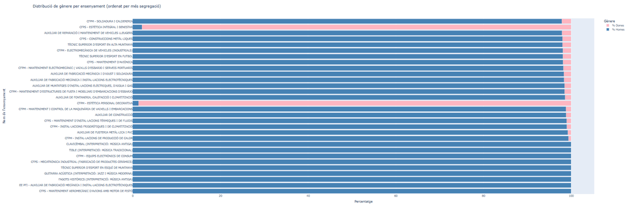

```python
import plotly.graph_objects as go

# Agrupació i càlculs
segregacio = df.groupby('Nom ensenyament').agg({
    'Matrícules. Homes': 'sum',
    'Matrícules. Dones': 'sum'
}).reset_index()

# Total i filtre
segregacio['Total'] = segregacio['Matrícules. Homes'] + segregacio['Matrícules. Dones']
segregacio = segregacio[segregacio['Total'] > 10]  # només estudis amb pes real

# Percentatges
segregacio['% Homes'] = (segregacio['Matrícules. Homes'] / segregacio['Total']) * 100
segregacio['% Dones'] = (segregacio['Matrícules. Dones'] / segregacio['Total']) * 100

# Índex de segregació
segregacio['Index segregació'] = abs(segregacio['% Homes'] - segregacio['% Dones'])

# Ordeno pel grau de desequilibri
segregacio = segregacio.sort_values('Index segregació', ascending=False).head(30)

# Gràfic apilat horitzontal
fig = go.Figure()

fig.add_trace(go.Bar(
    y=segregacio['Nom ensenyament'],
    x=segregacio['% Homes'],
    name='% Homes',
    orientation='h',
    marker_color='steelblue',
    hovertemplate='% Homes: %{x:.1f}%<extra></extra>'
))

fig.add_trace(go.Bar(
    y=segregacio['Nom ensenyament'],
    x=segregacio['% Dones'],
    name='% Dones',
    orientation='h',
    marker_color='lightpink',
    hovertemplate='% Dones: %{x:.1f}%<extra></extra>'
))

fig.update_layout(
    barmode='stack',
    title="Distribució de gènere per ensenyament (ordenat per més segregació)",
    xaxis_title='Percentatge',
    yaxis_title='Nom de l\'ensenyament',
    legend_title='Gènere',
    height=1000
)

# fig.show()
from IPython.display import Image
Image('/content/drive/MyDrive/Visualització de dades/imatge1.png')
```

- **Hi ha pressió educativa en determinats territoris o centres?**

Amb aquest gràfic podem veure en quines comarques la mitjana d'alumnes per unitat és més alta. Això pot voler dir que hi ha més demanda educativa i que les classes, per cada unitat, són més nombroses, estan més plenes.

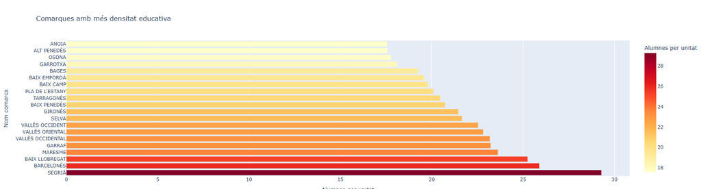

```python
import plotly.express as px

# Converteixo els noms de comarca a majúscula per evitar duplicats per format
df['Nom comarca'] = df['Nom comarca'].str.upper()

df_comarques = df.groupby('Nom comarca')['alumnes_per_unitat'].mean().reset_index()

fig2 = px.bar(
    df_comarques.sort_values('alumnes_per_unitat', ascending=False).head(20),
    x='alumnes_per_unitat',
    y='Nom comarca',
    orientation='h',
    color='alumnes_per_unitat',
    color_continuous_scale='YlOrRd',
    labels={'alumnes_per_unitat': 'Alumnes per unitat'},
    title='Comarques amb més densitat educativa'
)
# fig2.show()
from IPython.display import Image
Image('/content/drive/MyDrive/Visualització de dades/imatge2.png')
```

En aquest cas veiem que la majoria de les ràtios amb més alumnes es troba en l'àrea metropolitana, amb l'excepció del Segrià.

Per a analitzar si té a veure amb l'oferta de diferents tipus d'estudis realitzo un mapa de calor segons el tipus d'estudis i les comarques.

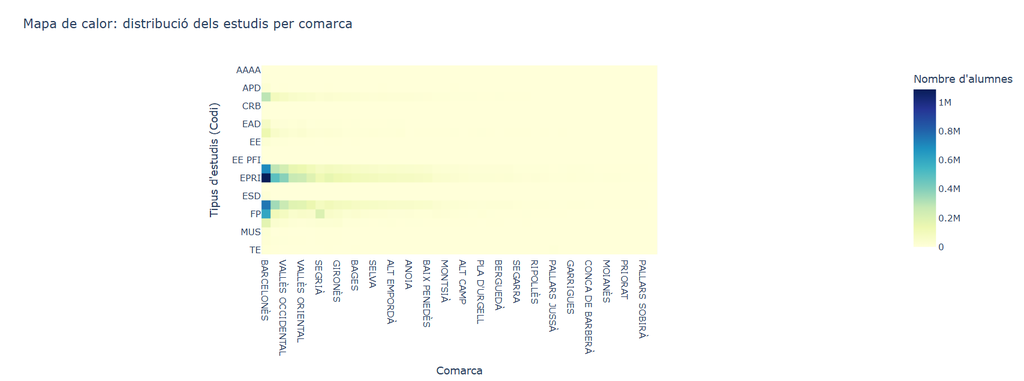

```python
# Agrupo les dades
heatmap_data = df.groupby(['Nom comarca', 'Codi estudis'])['Matrícules. Total'].sum().reset_index()

# Converteixo a majúscules per evitar duplicats
heatmap_data['Nom comarca'] = heatmap_data['Nom comarca'].str.upper()
pivot_df = heatmap_data.pivot(index='Codi estudis', columns='Nom comarca', values='Matrícules. Total').fillna(0)

# Gràfica amb les dimensions
fig5 = px.imshow(
    pivot_df,
    labels=dict(x="Comarca", y="Tipus d'estudis (Codi)", color="Nombre d'alumnes"),
    color_continuous_scale='YlGnBu',
    title="Mapa de calor: distribució dels estudis per comarca"
)
fig5.update_layout(xaxis={'categoryorder': 'total descending'})
#fig5.show()
from IPython.display import Image
Image('/content/drive/MyDrive/Visualització de dades/imatge3.png')
```

Observem que, com era d'esperar, les unitats amb més alumnes són les d'educacions obligatòries, com l'educació primària o secundària. I que on hi ha més varietat en les educacions és, també, en l'àrea metropolitana.

```
Gràfiques per la comarca: Alta Ribagorça

Gràfiques per la comarca: Garrotxa

Gràfiques per la comarca: Barcelonès
```

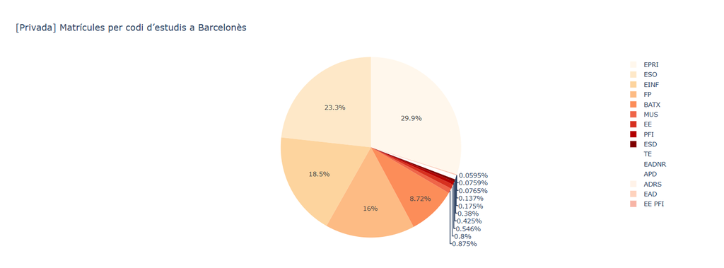

```python
# Normalitzo el nom de les comarques i titularitat
df['Nom comarca'] = df['Nom comarca'].str.upper()
df['Nom titularitat'] = df['Nom titularitat'].str.upper()

# Agrupo per comarca
comarques_agg = df.groupby('Nom comarca')['Matrícules. Total'].sum().reset_index()
comarques_ordenades = comarques_agg.sort_values('Matrícules. Total')

comarca_min = comarques_ordenades.iloc[0]['Nom comarca']
comarca_max = comarques_ordenades.iloc[-1]['Nom comarca']
comarca_mitjana = comarques_ordenades.iloc[len(comarques_ordenades) // 2]['Nom comarca']

comarques_objetiu = [comarca_min, comarca_mitjana, comarca_max]

for comarca in comarques_objetiu:
    print(f"\nGràfiques per la comarca: {comarca.title()}")

    # TOTAL
    sub_total = df[df['Nom comarca'] == comarca].groupby('Codi estudis')['Matrícules. Total'].sum().reset_index()
    sub_total = sub_total.sort_values('Matrícules. Total', ascending=False).head(15)

    fig_total = px.pie(
        sub_total,
        values='Matrícules. Total',
        names='Codi estudis',
        title=f"[Total] Matrícules per codi d’estudis a {comarca.title()}",
        color_discrete_sequence=px.colors.sequential.Blues
    )
   # fig_total.show()

    # PÚBLIC
    sub_public = df[
        (df['Nom comarca'] == comarca) & (df['Nom naturalesa'].str.contains("Públic"))
    ].groupby('Codi estudis')['Matrícules. Total'].sum().reset_index()
    sub_public = sub_public.sort_values('Matrícules. Total', ascending=False).head(15)

    fig_public = px.pie(
        sub_public,
        values='Matrícules. Total',
        names='Codi estudis',
        title=f"[Pública] Matrícules per codi d’estudis a {comarca.title()}",
        color_discrete_sequence=px.colors.sequential.Greens
    )
   # fig_public.show()

    # PRIVAT
    sub_privat = df[
        (df['Nom comarca'] == comarca) & (df['Nom naturalesa'].str.contains("Privat"))
    ].groupby('Codi estudis')['Matrícules. Total'].sum().reset_index()
    sub_privat = sub_privat.sort_values('Matrícules. Total', ascending=False).head(15)

    fig_privat = px.pie(
        sub_privat,
        values='Matrícules. Total',
        names='Codi estudis',
        title=f"[Privada] Matrícules per codi d’estudis a {comarca.title()}",
        color_discrete_sequence=px.colors.sequential.OrRd
    )
   # fig_privat.show()
from IPython.display import Image
Image('/content/drive/MyDrive/Visualització de dades/imatge4.png')
Image('/content/drive/MyDrive/Visualització de dades/imatge5.png')
Image('/content/drive/MyDrive/Visualització de dades/imatge6.png')
Image('/content/drive/MyDrive/Visualització de dades/imatge7.png')
Image('/content/drive/MyDrive/Visualització de dades/imatge8.png')
Image('/content/drive/MyDrive/Visualització de dades/imatge9.png')
Image('/content/drive/MyDrive/Visualització de dades/imatge10.png')
Image('/content/drive/MyDrive/Visualització de dades/imatge11.png')
Image('/content/drive/MyDrive/Visualització de dades/imatge12.png')
```

[figure not shown]

```python
import plotly.express as px

# municipi = input("Introdueix el nom del municipi: ")
municipi = "Castellterçol"

# TOTAL
sub_total = df[df['Nom municipi'] == municipi].groupby('Codi estudis')['Matrícules. Total'].sum().reset_index()
sub_total = sub_total.sort_values('Matrícules. Total', ascending=False).head(15)

if sub_total.empty:
    print(f"No hi ha dades per al municipi: {municipi}")
else:
    fig_total = px.pie(
        sub_total,
        values='Matrícules. Total',
        names='Codi estudis',
        title=f"[Total] Matrícules per codi d’estudis a {municipi}",
        color_discrete_sequence=px.colors.sequential.Blues
    )
    #fig_total.show()

    # PÚBLIC
    sub_public = df[
        (df['Nom municipi'] == municipi) & (df['Nom naturalesa'].str.contains("Públic"))
    ].groupby('Codi estudis')['Matrícules. Total'].sum().reset_index()
    sub_public = sub_public.sort_values('Matrícules. Total', ascending=False).head(15)

    fig_public = px.pie(
        sub_public,
        values='Matrícules. Total',
        names='Codi estudis',
        title=f"[Pública] Matrícules per codi d’estudis a {municipi}",
        color_discrete_sequence=px.colors.sequential.Greens
    )
    #fig_public.show()

    # PRIVAT
    sub_privat = df[
        (df['Nom municipi'] == municipi) & (df['Nom naturalesa'].str.contains("Privat"))
    ].groupby('Codi estudis')['Matrícules. Total'].sum().reset_index()
    sub_privat = sub_privat.sort_values('Matrícules. Total', ascending=False).head(15)

    fig_privat = px.pie(
        sub_privat,
        values='Matrícules. Total',
        names='Codi estudis',
        title=f"[Privada] Matrícules per codi d’estudis a {municipi}",
        color_discrete_sequence=px.colors.sequential.OrRd
    )
    #fig_privat.show()
from IPython.display import Image
Image('/content/drive/MyDrive/Visualització de dades/imatge13.png')
Image('/content/drive/MyDrive/Visualització de dades/imatge14.png')
Image('/content/drive/MyDrive/Visualització de dades/imatge15.png')
```

- **Hi ha segregació segons públic o privat?**

Analitzo si hi ha diferències notables entre les inscripcions en centres públics o privats.

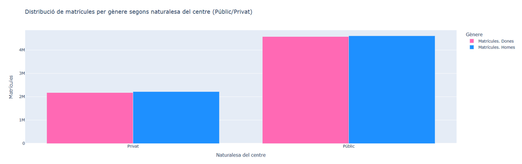

```python
import plotly.express as px

df_naturalesa_genere = df.groupby('Nom naturalesa')[['Matrícules. Dones', 'Matrícules. Homes']].sum().reset_index()

fig1 = px.bar(
    df_naturalesa_genere.melt(id_vars='Nom naturalesa', var_name='Gènere', value_name='Matrícules'),
    x='Nom naturalesa',
    y='Matrícules',
    color='Gènere',
    barmode='group',
    title='Distribució de matrícules per gènere segons naturalesa del centre (Públic/Privat)',
    labels={'Nom naturalesa': 'Naturalesa del centre'},
    color_discrete_map={
        'Matrícules. Dones': 'hotpink',
        'Matrícules. Homes': 'dodgerblue'
    }
)
#fig1.show()
from IPython.display import Image
Image('/content/drive/MyDrive/Visualització de dades/imatge16.png')
```

No s'observen diferències notables de segregació de gènere segons públic o privat.

Analitzem, també, si per tipus d'estudis sí que n'hi ha:

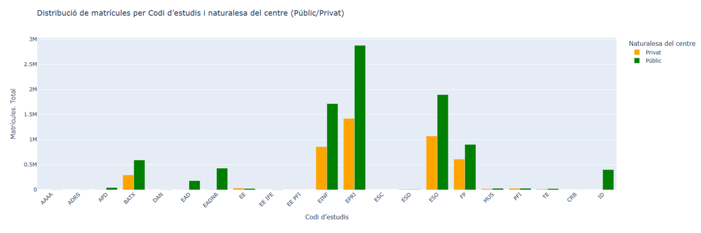

```python
# Agrupo les matrícules per Codi d'estudis i naturalesa (Públic/Privat)
df_estudis_naturalesa = df.groupby(['Codi estudis', 'Nom naturalesa'])[['Matrícules. Total']].sum().reset_index()

import plotly.express as px

fig = px.bar(
    df_estudis_naturalesa,
    x='Codi estudis',
    y='Matrícules. Total',
    color='Nom naturalesa',
    barmode='group',
    title='Distribució de matrícules per Codi d’estudis i naturalesa del centre (Públic/Privat)',
    color_discrete_map={
        'Públic': 'green',
        'Privat': 'orange'
    },
    labels={'Codi estudis': 'Codi d’estudis', 'Nom naturalesa': 'Naturalesa del centre'}
)

fig.update_layout(xaxis_tickangle=-45)
#fig.show()
from IPython.display import Image
Image('/content/drive/MyDrive/Visualització de dades/imatge17.png')
```

**6. Conclusions**

**7. Reflexió final i passos futurs**

Amb aquest conjunt de dades he après com es distribueix l'educació a Catalunya. A més, per a analitzar-ho he pogut aprofundir amb les tècniques que he utilitzat, sobretot amb el codi amb Python i en la realització de gràfiques molt diverses.

Algunes limitacions que he trobat són que les coordenades no se'm mostraven correctament en els mapes, cosa que no m'ha permès analitzar aquesta part de forma més visual, i això crec que hagués ajudat molt a veure les anàlisis per zones.

Si hagués tingut més temps m'hauria agradat poder analitzar en més detall els diferents tipus d'estudi, poder centrar-me en cada un dels Codis d'Estudi per poder analitzar-ne els subgrups, per exemple, en el cas de Batxillerat poder analitzar si hi ha diferències notables segons la modalitat, si hi ha batxillerats que només s'ofereixen en certes poblacions, si hi ha diferències de gènere notables en les modalitats...